# linear_regression

## Intro

Working through chapter 4 on simple linear regression.

[Book Github](https://github.com/MatsuuraKentaro/Bayesian_Statistical_Modeling_with_Stan_R_and_Python/tree/master)

```r
knitr::opts_chunk$set(warning = FALSE, message = FALSE)
# Libraries
library(tidyverse)
library(cmdstanr)
library(posterior)
library(bayesplot)
color_scheme_set("viridis")
```

Loading salary data. Note, path may change when trying to render or work interactively.

```r
# interactive path
salary = read_csv('./data/data-salary.csv')

head(salary)
```

```
# A tibble: 6 × 2
      X     Y
  <dbl> <dbl>
1     7  45.7
2    10  48.2
3    16  51.8
4    25  53.5
5     5  42.7
6    25  60.3
```

Scatter plot of salary.

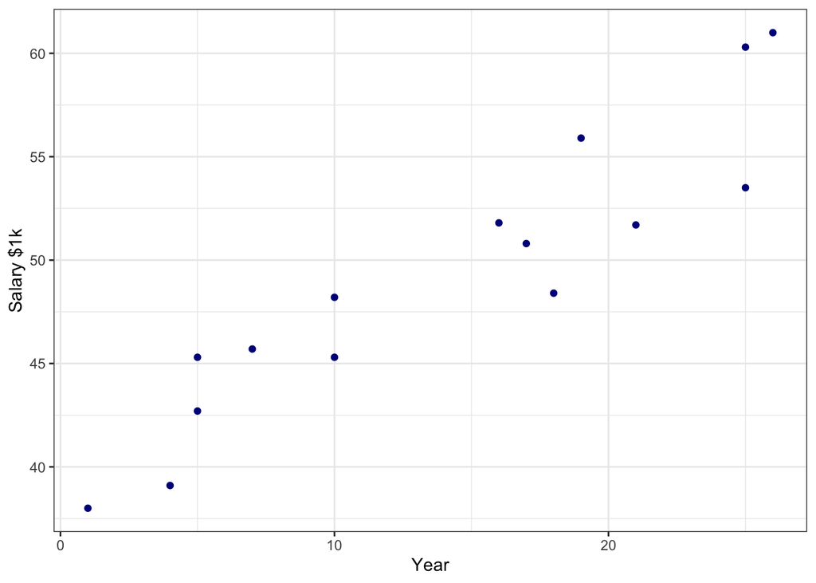

```r
ggplot(data = salary, aes(x = X, y = Y)) +
  geom_point(color = 'darkblue') +
  xlab('Year') +
  ylab('Salary $1k') +
  theme_bw()
```

**Model Formula 4.1**

Where $n = 1,...,N$

$$Y[n] = y_{\text{base}}[n] + \epsilon[n] \\
y_{\text{base}} = \alpha + b X[n] \\
\epsilon[n] \backsim N(0,\mu)
\tag{1}$$

Can be reduced to the parameters to be estimated…

$$Y[n] \backsim N(\mu = \alpha + bX[n], \sigma)$$

### Maximum likelihood estimation of the model

Can model using lm function or glm.

```r
# linear model
res_lm = lm(Y ~ X, data = salary)

summary(res_lm)
```

```
Call:
lm(formula = Y ~ X, data = salary)

Residuals:
    Min      1Q  Median      3Q     Max
-4.0063 -2.0278  0.2412  2.3603  2.9080

Coefficients:
            Estimate Std. Error t value Pr(>|t|)
(Intercept) 38.69687    1.33429  29.002 3.35e-13 ***
X            0.75238    0.08261   9.107 5.26e-07 ***
---
Signif. codes:  0 '***' 0.001 '**' 0.01 '*' 0.05 '.' 0.1 ' ' 1

Residual standard error: 2.614 on 13 degrees of freedom
Multiple R-squared:  0.8645,    Adjusted R-squared:  0.8541
F-statistic: 82.95 on 1 and 13 DF,  p-value: 5.264e-07
```

Confidence and prediction intervals from the linear model.

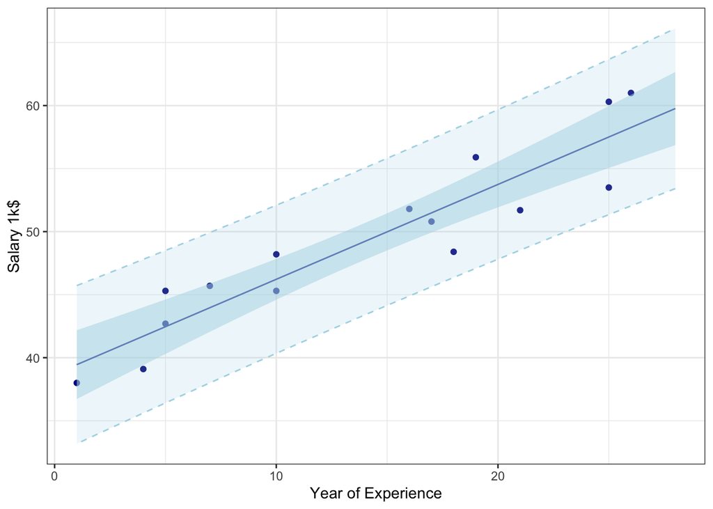

```r
# prediction dataframe
X_pred = data.frame(X = 1:28)
# confidence interval
conf_95 = predict(res_lm , X_pred, interval = 'confidence')
# prediction interval
pred_95 = predict(res_lm, X_pred, interval = 'prediction')
# plot data
plot_data = cbind(X_pred, conf_95)
# prediction data
pred_data = cbind(X_pred, pred_95)

ggplot() +
  geom_point(
    data = salary,
    aes(x = X, y = Y),
    color = 'darkblue'
  ) +
  geom_line(
    data = plot_data,
    aes(x = X, y = fit),
    color = 'darkblue'
    ) +
  geom_ribbon(
    data = plot_data,
    aes(x = X, ymin = lwr, ymax = upr),
    alpha = 0.5,
    fill = 'lightblue'
    ) +
  geom_ribbon(
    data = pred_data,
    aes(x = X, ymin = lwr, ymax = upr),
    alpha = 0.2,
    fill = 'lightblue',
    color = 'lightblue',
    linetype = 'dashed'
    ) +
  labs(x = 'Year of Experience', y = 'Salary 1k$') +
  theme_bw()
```

### Bayesian linear model in STAN

Fitting of model 4 defined in stan folder.

```r
# data as a list
d = list(N = nrow(salary), X = salary$X , Y = salary$Y)

# load model
model.4 = cmdstan_model(
  stan_file = './stan/model4.stan'
  )

# fit model to data
fit.4 = model.4$sample(data = d, seed = 123)
```

[output not shown]

[output cut: 43 more lines]

[output not shown]

```r
# get posterior draws
# default is a 3-D draws_array object from the posterior package
# iterations x chains x variables
draws_arr <- fit.4$draws() # or format="array"
str(draws_arr)
```

```
 'draws_array' num [1:1000, 1:4, 1:4] -21.8 -21 -20.6 -20.7 -21.3 ...
 - attr(*, "dimnames")=List of 3
  ..$ iteration: chr [1:1000] "1" "2" "3" "4" ...
  ..$ chain    : chr [1:4] "1" "2" "3" "4"
  ..$ variable : chr [1:4] "lp__" "a" "b" "sigma"
```

Summary of model.

```r
# cmdstan_summary give more detail than fit.4$summary()
fit.4$cmdstan_summary()
```

```
Inference for Stan model: model4_model
4 chains: each with iter=(1000,1000,1000,1000); warmup=(0,0,0,0); thin=(1,1,1,1); 4000 iterations saved.

Warmup took (0.016, 0.013, 0.014, 0.019) seconds, 0.062 seconds total
Sampling took (0.016, 0.016, 0.015, 0.018) seconds, 0.065 seconds total

                Mean     MCSE  StdDev    5%   50%   95%  N_Eff  N_Eff/s    R_hat

lp__             -22  3.7e-02     1.3   -24   -21   -20   1299    19988      1.0
accept_stat__   0.91  2.9e-03    0.13  0.64  0.96   1.0   2126    32707  1.0e+00
stepsize__      0.35  2.0e-02   0.028  0.33  0.36  0.40    2.0       31  1.9e+13
treedepth__      2.8  1.4e-02    0.74   2.0   3.0   4.0   2894    44519  1.0e+00
n_leapfrog__     8.6  1.1e-01     4.5   3.0   7.0    15   1693    26050  1.0e+00
divergent__     0.00      nan    0.00  0.00  0.00  0.00    nan      nan      nan
energy__          23  5.0e-02     1.8    21    23    26   1297    19947  1.0e+00

a                 39  4.3e-02     1.5    36    39    41   1273    19580      1.0
b               0.75  2.6e-03   0.093  0.60  0.75  0.90   1291    19864      1.0
sigma            2.9  1.6e-02    0.63   2.1   2.8   4.1   1528    23502      1.0

Samples were drawn using hmc with nuts.
For each parameter, N_Eff is a crude measure of effective sample size,
and R_hat is the potential scale reduction factor on split chains (at
convergence, R_hat=1).
```

Plot of parameters.

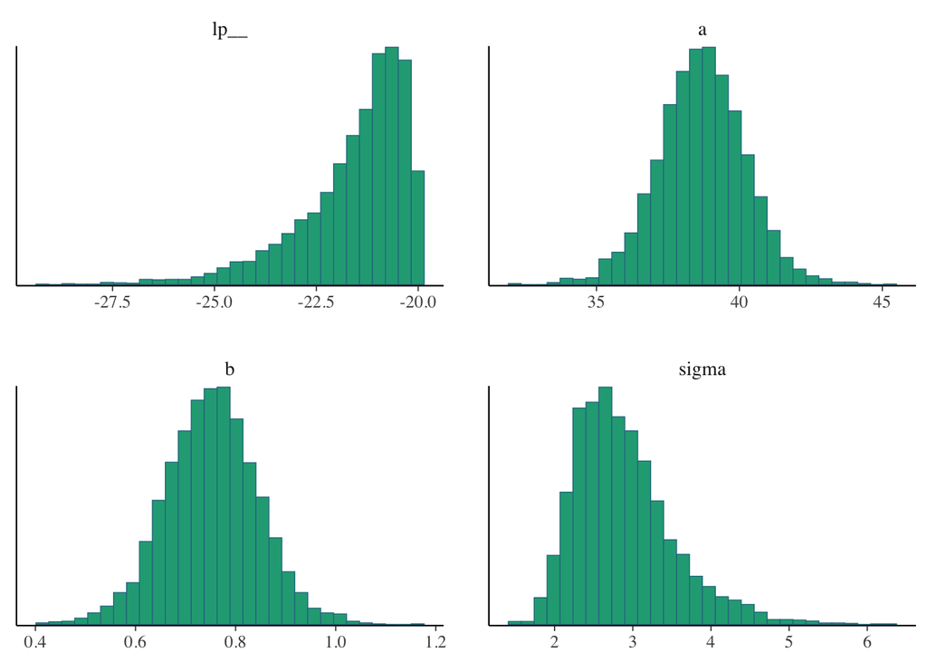

```r
mcmc_hist(fit.4$draws())
```

Example of how to save model results can be found on page 52, section 4.2.3. Skipping that here.

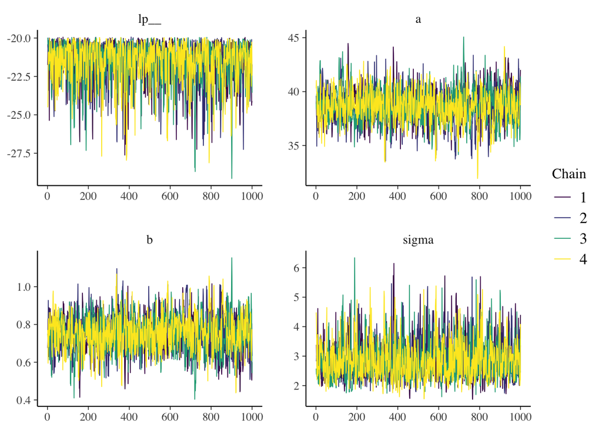

```r
mcmc_trace(fit.4$draws())
```

Note, section 4.2.4 has some useful notes on adjusting the MCMC settings.

### Using the posterior

Can use the $draw function to extract draws.

```r
# draw model 4 as dataframe
draw_model4 = fit.4$draws(format = "df")
# can also use 'format = "matrix"' if you'd like the matrix
```

Can calculate desired quantiles.

```r
quantile(draw_model4$b, probs = c(0.025, 0.975))
```

```
     2.5%     97.5%
0.5664019 0.9351742
```

Plot of posterior draws of alpha and beta.

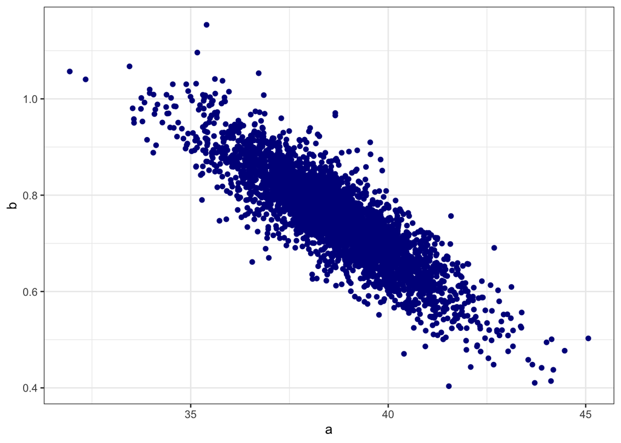

```r
ggplot(draw_model4, aes( x = a , y = b)) +
  geom_point(color = 'darkblue') +
  theme_bw()
```

#### Bayesian credible intervals and prediction intervals

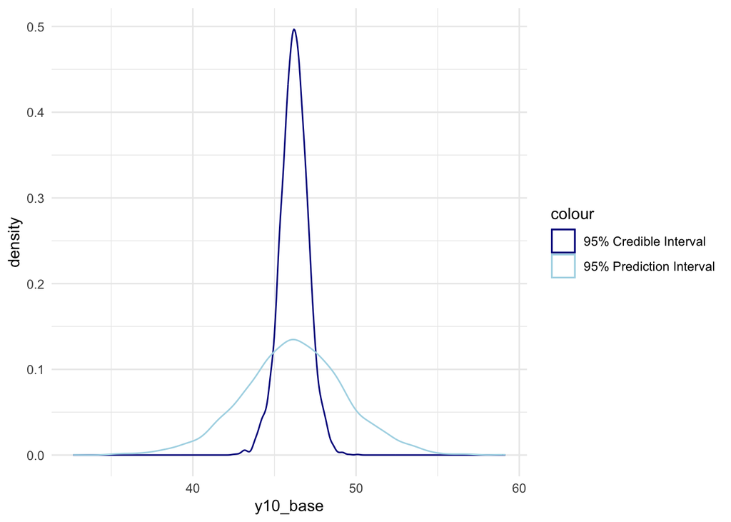

```r
N_ms = nrow(draw_model4)
y10_base = draw_model4$a + draw_model4$b * 10
y10_pred = rnorm(n = N_ms, mean = y10_base, sd = draw_model4$sigma)

ggplot() +
  geom_density(
    mapping = aes(y10_base, color = '95% Credible Interval')
    ) +
  geom_density(
    mapping = aes(y10_pred, color = '95% Prediction Interval')
    ) +
  scale_color_manual( values = c('darkblue', 'lightblue')) +
  theme_minimal()
```

Bayesian confidence intervals from posterior.

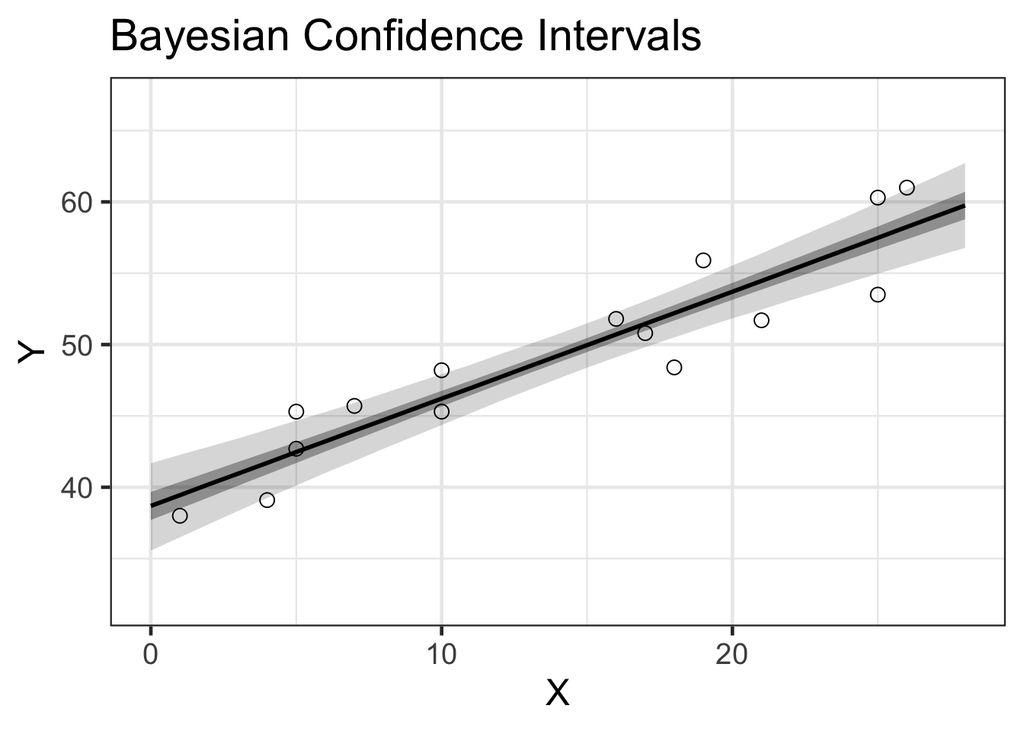

```r
N_ms = nrow(draw_model4)
Xp = seq(0, 28, by = 1)
Np = length(Xp)

set.seed(123)

yp_base_ms = matrix(nrow=N_ms, ncol=Np)
yp_ms = matrix(nrow=N_ms, ncol=Np)

for (n in 1:Np) {
  yp_base_ms[,n] = draw_model4$a + draw_model4$b * Xp[n]
  yp_ms[,n] = rnorm(n=N_ms, mean=yp_base_ms[,n], sd=draw_model4$sigma)
}


qua = apply(yp_base_ms, 2, quantile, probs=c(0.025, 0.25, 0.50, 0.75, 0.975))
d_est = data.frame(X=Xp, t(qua), check.names = FALSE)


p = ggplot() +
  theme_bw(base_size=18) +
  geom_ribbon(data=d_est, aes(x=X, ymin=`2.5%`, ymax=`97.5%`), fill='black', alpha=1/6) +
  geom_ribbon(data=d_est, aes(x=X, ymin=`25%`, ymax=`75%`), fill='black', alpha=2/6) +
  geom_line(data=d_est, aes(x=X, y=`50%`), linewidth=1, color = 'black') +
  geom_point(data=salary, aes(x=X, y=Y), shape=1, size=3, color = 'black') +
  coord_cartesian(ylim = c(32, 67)) +
  scale_y_continuous(breaks=seq(40, 60, 10)) +
  labs(y='Y') +
  ggtitle('Bayesian Confidence Intervals')

p
```

Bayesian prediction intervals from posterior.

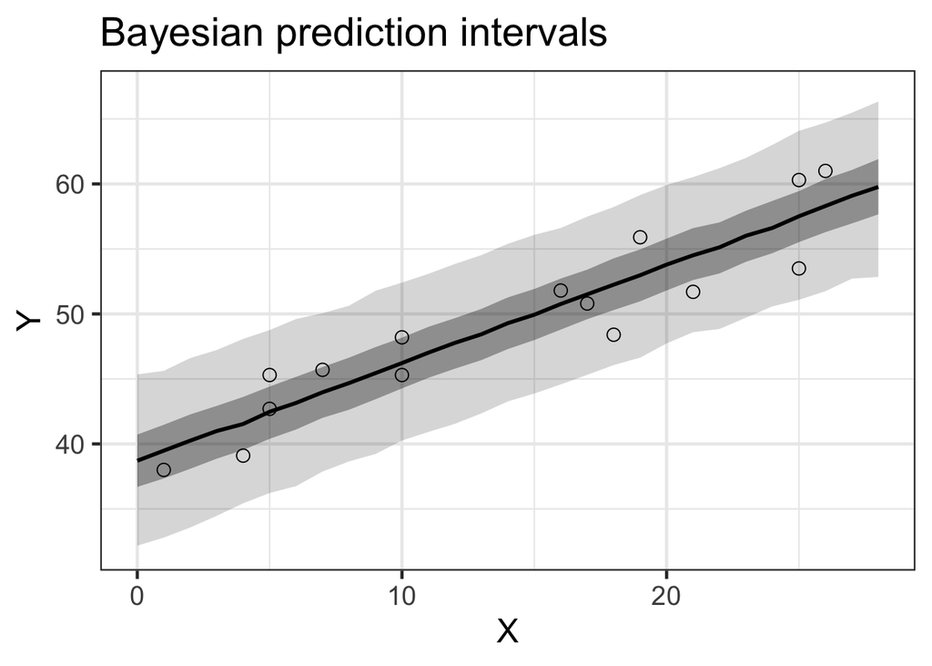

```r
qua <- apply(yp_ms, 2, quantile, probs=c(0.025, 0.25, 0.50, 0.75, 0.975))
d_est <- data.frame(X=Xp, t(qua), check.names = FALSE)

p <- ggplot() +
  theme_bw(base_size=18) +
  geom_ribbon(data=d_est, aes(x=X, ymin=`2.5%`, ymax=`97.5%`), fill='black', alpha=1/6) +
  geom_ribbon(data=d_est, aes(x=X, ymin=`25%`, ymax=`75%`), fill='black', alpha=2/6) +
  geom_line(data=d_est, aes(x=X, y=`50%`), color = 'black', linewidth=1) +
  geom_point(data=salary, aes(x=X, y=Y), color = 'black', shape=1, size=3) +
  coord_cartesian(ylim = c(32, 67)) +
  scale_y_continuous(breaks=seq(40, 60, 10)) +
  labs(y='Y') +
  ggtitle('Bayesian prediction intervals')

p
```

#### Handling the posterior using transformed parameters and generated quantities

Using transformed parameters and generated quantities instead of the posterior object.

- Easier to use when calculations using the posterior become complicated
- Can speed up calculations

```r
# Define xp and np
Xp <- seq(0, 28, by = 1)
Np <- length(Xp)

# data as a list
d = list(N = nrow(salary), X = salary$X , Y = salary$Y, Xp = Xp, Np = Np)

# load model
model.4b = cmdstan_model(
  stan_file = './stan/model4-b.stan'
  )

# fit model to data
fit.4b = model.4b$sample(data = d, seed = 123)
```

[output not shown]

[output cut: 43 more lines]

[output not shown]

Now we can draw posterior samples from the generated quantities block and make plot of median, 50% credible interval and 95% credible interval.

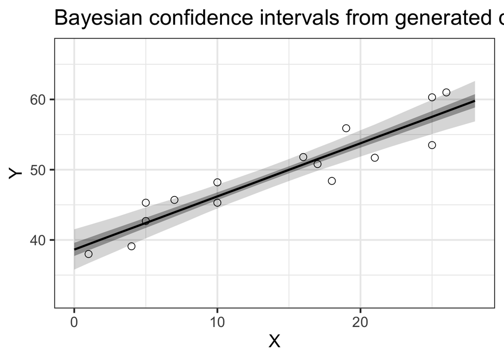

```r
# get posterior draws
# default is a 3-D draws_array object from the posterior package
# iterations x chains x variables
yp_base_ms <- fit.4b$draws('yp_base', format='matrix')
yp_ms      <- fit.4b$draws('yp', format='matrix')


qua <- apply(yp_base_ms, 2, quantile, probs=c(0.025, 0.25, 0.50, 0.75, 0.975))
d_est <- data.frame(X=Xp, t(qua), check.names = FALSE)

p <- ggplot() +
  theme_bw(base_size=18) +
  geom_ribbon(data=d_est, aes(x=X, ymin=`2.5%`, ymax=`97.5%`), fill='black', alpha=1/6) +
  geom_ribbon(data=d_est, aes(x=X, ymin=`25%`, ymax=`75%`), fill='black', alpha=2/6) +
  geom_line(data=d_est, aes(x=X, y=`50%`), size=1, color = 'black') +
  geom_point(data=salary, aes(x=X, y=Y), shape=1, size=3, color = 'black') +
  coord_cartesian(ylim = c(32, 67)) +
  scale_y_continuous(breaks=seq(40, 60, 10)) +
  labs(y='Y') +
  ggtitle('Bayesian confidence intervals from generated quantities')

p
```

Prediction interval plot from the generated quantities posterior.

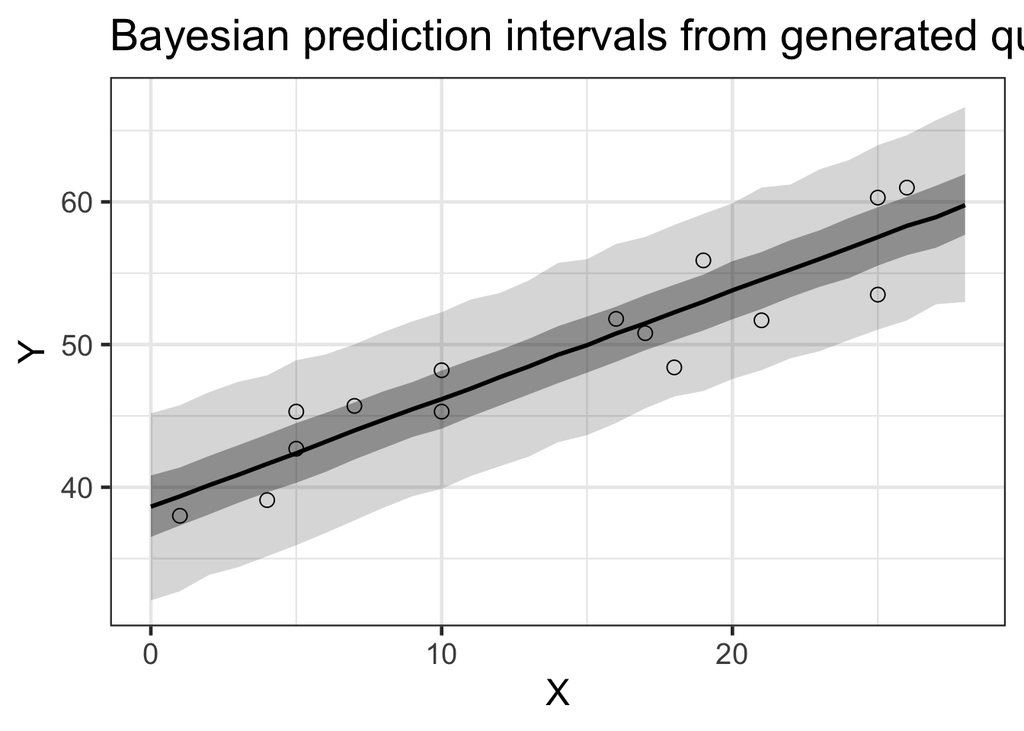

```r
qua <- apply(yp_ms, 2, quantile, probs=c(0.025, 0.25, 0.50, 0.75, 0.975))
d_est <- data.frame(X=Xp, t(qua), check.names = FALSE)


p <- ggplot() +
  theme_bw(base_size=18) +
  geom_ribbon(data=d_est, aes(x=X, ymin=`2.5%`, ymax=`97.5%`), fill='black', alpha=1/6) +
  geom_ribbon(data=d_est, aes(x=X, ymin=`25%`, ymax=`75%`), fill='black', alpha=2/6) +
  geom_line(data=d_est, aes(x=X, y=`50%`), size=1, color = 'black') +
  geom_point(data=salary, aes(x=X, y=Y), shape=1, size=3, color = 'black') +
  coord_cartesian(ylim = c(32, 67)) +
  scale_y_continuous(breaks=seq(40, 60, 10)) +
  labs(y='Y') +
  ggtitle('Bayesian prediction intervals from generated quantities')

p
```

## Supplement

### T-test

Two-sample t-test in STAN. Start with simulating data.

```r
set.seed(123)
N1 = 30
N2 = 20
Y1 = rnorm(n = N1, mean = 0, sd = 5)
Y2 = rnorm(n = N2, mean = 1, sd = 4)
```

1. Visualizing distributions of Y1 and Y2, looks like there isn’t much difference in distributions.

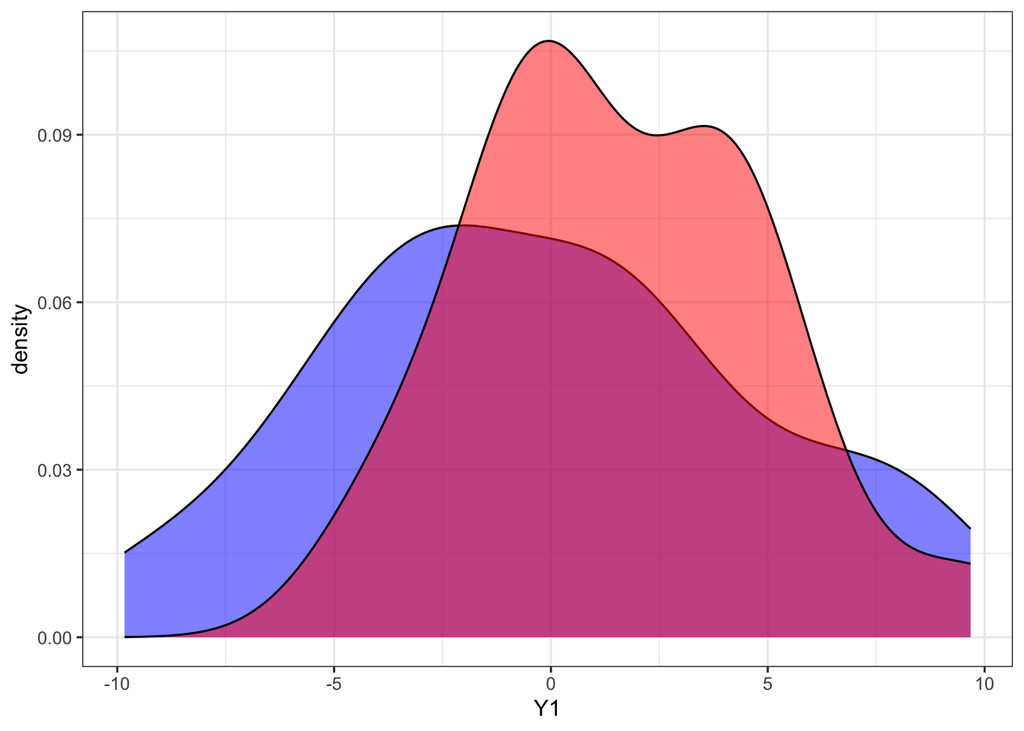

```r
# vis
ggplot() +
  geom_density(mapping = aes(Y1), fill = 'blue', alpha = 0.5) +
  geom_density(mapping = aes(Y2), fill = 'red', alpha = 0.5) +
  theme_bw()
```

2. Two-sample test using Student’s T.

$$t = \frac{\bar{x}_1 - \bar{x}_2}{s_p \sqrt{\frac{1}{n_1} + \frac{1}{n_2}}}$$

```r
t.test(Y1, Y2, var.equal = TRUE)
```

```
    Two Sample t-test

data:  Y1 and Y2
t = -1.4772, df = 48, p-value = 0.1461
alternative hypothesis: true difference in means is not equal to 0
95 percent confidence interval:
 -4.3967325  0.6723788
sample estimates:
 mean of x  mean of y
-0.2355188  1.6266580
```

3. STAN model for two sample t-test.

```r
# data as a list
t_test_data = list(N1 = N1, Y1 = Y1 , N2 = N2, Y2 = Y2)


# load model
model.t = cmdstan_model(
  stan_file = './stan/t_test.stan'
  )


# fit model
fit.t = model.t$sample(data = t_test_data, seed = 123)
```

[output not shown]

[output cut: 43 more lines]

[output not shown]

```r
fit.t$summary()
```

```
# A tibble: 4 × 10
  variable    mean  median    sd   mad        q5    q95  rhat ess_bulk ess_tail
  <chr>      <num>   <num> <num> <num>     <num>  <num> <num>    <num>    <num>
1 lp__     -97.8   -97.5   1.28  1.06  -100.     -96.4   1.00    1842.    2611.
2 mu1       -0.224  -0.246 0.825 0.790   -1.54     1.20  1.00    3796.    2879.
3 mu2        1.62    1.62  1.02  1.02    -0.0822   3.30  1.00    4809.    3142.
4 sigma      4.49    4.45  0.481 0.470    3.78     5.33  1.00    4094.    3274.
```

Check trace of model. Looks fine.

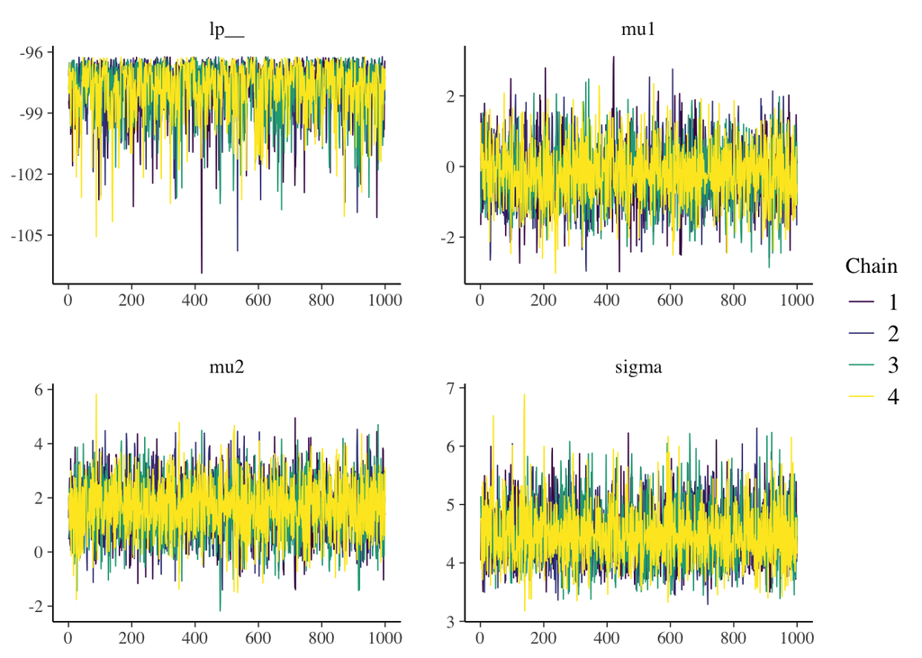

```r
mcmc_trace(fit.t$draws())
```

Extract draws.

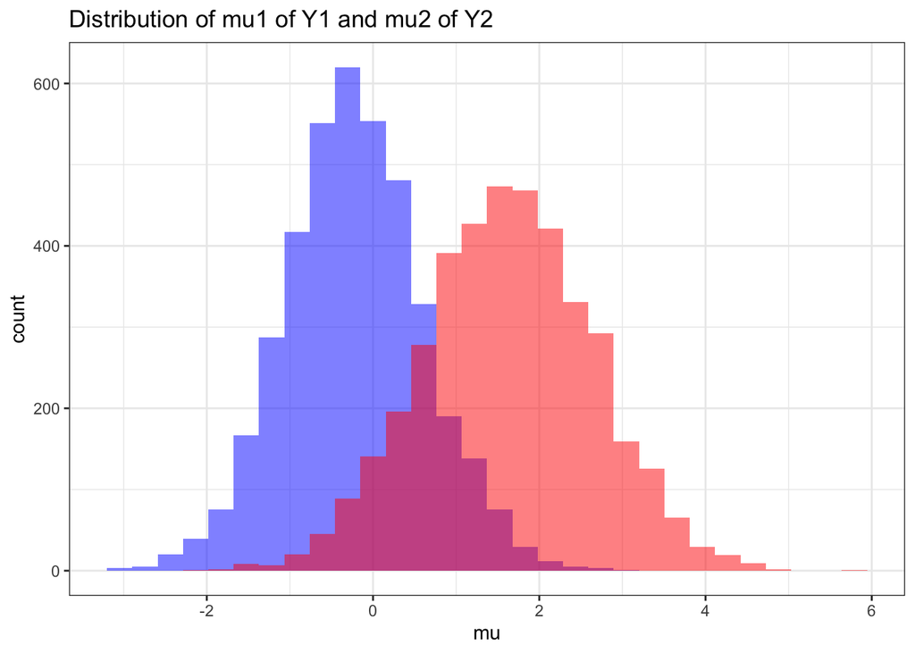

```r
# extact posterior draws for mu1
mu_post = fit.t$draws(c('mu1', 'mu2'), format = 'matrix')

# plot of distributions
ggplot(data = data.frame(mu_post)) +
  geom_histogram(aes(x = mu1), fill = 'blue', alpha = 0.5) +
  geom_histogram(aes(x = mu2), fill = 'red', alpha = 0.5) +
  theme_bw() +
  labs(x = 'mu', y = 'count') +
  ggtitle('Distribution of mu1 of Y1 and mu2 of Y2')
```

4. Computing probability of $Pr[\mu_1 < \mu_2]$ using posterior draws. Looks like $Pr[\mu_1 < \mu_2]$ ~ 0.92.

```r
mean( mu_post[, 'mu1'] < mu_post[, 'mu2'] )
```

```
[1] 0.91675
```

Calculating equivalent of p-value $Pr[(\mu_1 - \mu_2) < 0]$ another way.

```r
# can take the mean of true/false too since it's the same as above.
mean( (mu_post[, 'mu1'] - mu_post[, 'mu2']) < 0 )
```

```
[1] 0.91675
```

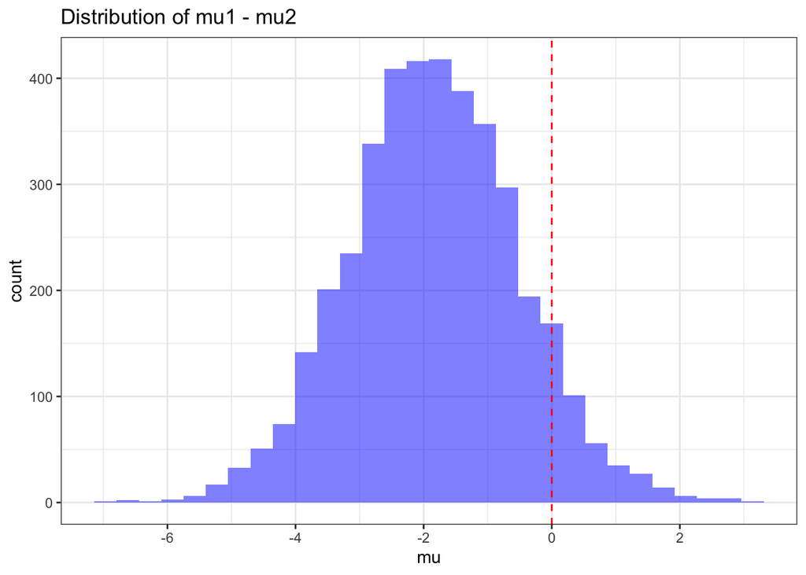

```r
ggplot(data = tibble(delta = mu_post[, 'mu1'] - mu_post[, 'mu2'])) +
  geom_histogram(aes(x = delta), fill = 'blue', alpha = 0.5) +
  geom_vline(xintercept = 0, color = 'red', linetype = 'dashed') +
  theme_bw() +
  labs(x = 'mu', y = 'count') +
  ggtitle('Distribution of mu1 - mu2')
```

5. Now do all the above sets but for unequal SDs.

```r
# welch / saither
t.test(Y1, Y2, var.equal = FALSE)
```

```
    Welch Two Sample t-test

data:  Y1 and Y2
t = -1.5884, df = 47.914, p-value = 0.1188
alternative hypothesis: true difference in means is not equal to 0
95 percent confidence interval:
 -4.2195205  0.4951669
sample estimates:
 mean of x  mean of y
-0.2355188  1.6266580
```

STAN Welch’s T.

```r
# load model
model.tw = cmdstan_model(
  stan_file = './stan/welch_t_test.stan'
  )


# fit model
fit.tw = model.tw$sample(data = t_test_data, seed = 123)
```

[output not shown]

[output cut: 43 more lines]

[output not shown]

```r
fit.tw$summary()
```

```
# A tibble: 5 × 10
  variable    mean  median    sd   mad      q5    q95  rhat ess_bulk ess_tail
  <chr>      <num>   <num> <num> <num>   <num>  <num> <num>    <num>    <num>
1 lp__     -95.4   -95.0   1.47  1.27  -98.2   -93.6   1.00    1836.    2177.
2 mu1       -0.253  -0.269 0.955 0.928  -1.79    1.32  1.00    4437.    2857.
3 mu2        1.64    1.65  0.805 0.772   0.347   2.97  1.00    3695.    2579.
4 sigma1     5.13    5.03  0.728 0.678   4.14    6.46  1.00    3902.    2634.
5 sigma2     3.63    3.54  0.643 0.612   2.73    4.79  1.00    4001.    2715.
```

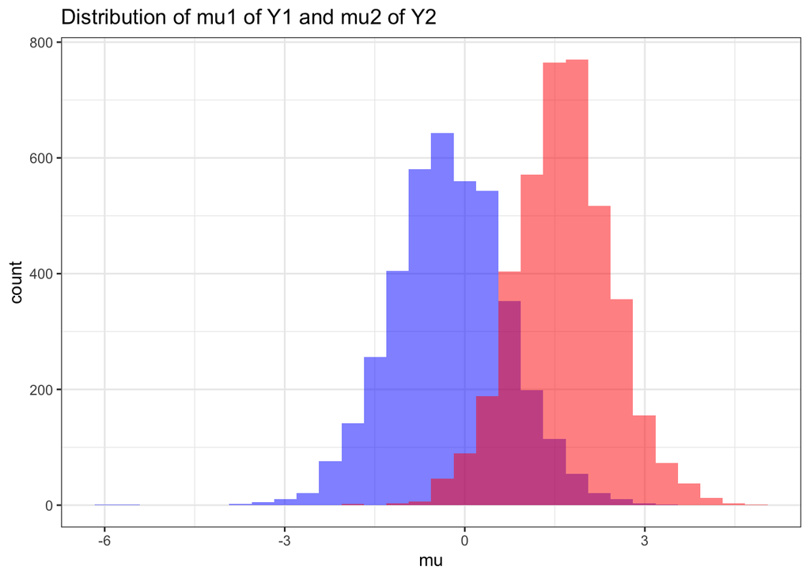

```r
# extact posterior draws for mu1
mu_post_welch = fit.tw$draws(c('mu1', 'mu2'), format = 'matrix')

# plot of distributions
ggplot(data = data.frame(mu_post_welch)) +
  geom_histogram(aes(x = mu1), fill = 'blue', alpha = 0.5) +
  geom_histogram(aes(x = mu2), fill = 'red', alpha = 0.5) +
  theme_bw() +
  labs(x = 'mu', y = 'count') +
  ggtitle('Distribution of mu1 of Y1 and mu2 of Y2')
```

Calculating $Pr[\mu_1 < \mu_2]$

```r
mean( mu_post_welch[, 'mu1'] < mu_post_welch[, 'mu2'] )
```

```
[1] 0.9345
```

### Example of maximum likelihood estimation

Simulation of simple linear example.

```r
set.seed(321)
# Sample size
sample_size = 1000
# Vector of X
x = rnorm(sample_size, mean = 0 , sd = 2)
# True parameters
true_beta0 = 2
true_beta1 = 5
# Relationship with Y
y = true_beta0 + true_beta1 * x + rnorm(sample_size, mean = 0, sd = 2)
```

Plot of sample data.

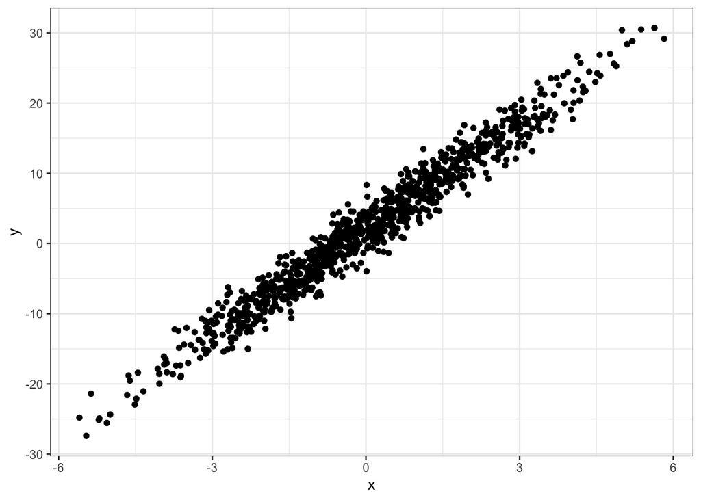

```r
p = ggplot(data = tibble(x,y), aes(x,y)) +
    geom_point() +
    theme_bw()

p
```

```r
# Define the negative log-likelihood function for the linear regression model
neg_log_likelihood_function <- function(parameters) {
  beta0 <- parameters[1]
  beta1 <- parameters[2]

  # Calculate the predicted values using the current parameter estimates
  y_pred <- beta0 + beta1 * x

  # Calculate the negative log-likelihood using the normal distribution assumption for errors
  neg_log_likelihood <- -sum(dnorm(y, mean = y_pred, sd = 10, log = TRUE))

  return(neg_log_likelihood)
}

# Use true parameters as initial guesses for beta0 and beta1
initial_guess <- c(5, 2)

# Find the maximum likelihood estimates using the 'nlm' function
mle_result <- nlm(f = neg_log_likelihood_function, p = initial_guess)

# Extract the parameter estimates from the optimization result
mle_beta0 <- mle_result$estimate[1]
mle_beta1 <- mle_result$estimate[2]

# Print the estimated beta0 and beta1
cat(sprintf("Estimated beta0: %.2f , true beta0: %.2f ", mle_beta0, true_beta0))
```

```
Estimated beta0: 2.03 , true beta0: 2.00
```

```r
cat(sprintf("Estimated beta1: %.2f , true beta1: %.2f ", mle_beta1, true_beta1))
```

```
Estimated beta1: 5.00 , true beta1: 5.00
```